# Calidad de Software con modelos predictivos

## Proyecto de Clasificación

**Presenta:**

Marvin Salvador Bacilio Anota

**Profesora:**

Dra. Verónica Rodríguez López

Fecha: 6 de febrero de 2026

El conjunto de datos está compuesto por 622 instancias y no presenta valores faltantes, ya que todas las columnas tienen un conteo completo de observaciones. Esto garantiza que no es necesario aplicar técnicas de imputación y que los análisis posteriores no se ven afectados por datos incompletos.

La mayoría de las variables corresponden a atributos de calidad del software y están codificadas de forma binaria (0/1). Esto se confirma observando que los valores mínimos y máximos son 0 y 1 respectivamente, y que las medias representan proporciones de ocurrencia.

```python
import pandas as pd
import matplotlib.pyplot as plt
import seaborn as sns

# -------------------------
# 1. Cargar datos (Windows)
# -------------------------
ruta = r"C:\Users\Marvin Anota\Documents\GitHub\Proyecto-Veronica\PROMISE-relabeled-NICE.csv"
df = pd.read_csv(ruta)
```

```python
display(df.head())
print("Dimensiones:", df.shape)
```

|  | ProjectID | RequirementText | IsFunctional | IsQuality | Availability (A) | Fault Tolerance (FT) | Legal (L) | Look & Feel (LF) | Maintainability (MN) | Operability (O) | Performance (PE) | Portability (PO) | Scalability (SC) | Security (SE) | Usability (US) | Other (OT) |
| --- | --- | --- | --- | --- | --- | --- | --- | --- | --- | --- | --- | --- | --- | --- | --- | --- |
| 0 | 1 | 'The system shall refresh the display every 60... | 1 | 1 | 0 | 0 | 0 | 0 | 0 | 0 | 1 | 0 | 0 | 0 | 0 | 0 |
| 1 | 1 | 'The application shall match the color of the ... | 0 | 1 | 0 | 0 | 1 | 1 | 0 | 0 | 0 | 0 | 0 | 0 | 0 | 0 |
| 2 | 1 | 'If projected the data must be readable. On a ... | 0 | 1 | 0 | 0 | 0 | 1 | 0 | 0 | 0 | 0 | 0 | 0 | 1 | 0 |
| 3 | 1 | 'The product shall be available during normal ... | 0 | 1 | 1 | 0 | 0 | 0 | 0 | 0 | 0 | 0 | 0 | 0 | 0 | 0 |
| 4 | 1 | 'If projected the data must be understandable.... | 0 | 1 | 0 | 0 | 0 | 1 | 0 | 0 | 0 | 0 | 0 | 0 | 1 | 0 |

```
Dimensiones: (622, 16)
```

```python
df.info()
```

```
<class 'pandas.core.frame.DataFrame'>
RangeIndex: 622 entries, 0 to 621
Data columns (total 16 columns):
 #   Column                Non-Null Count  Dtype
---  ------                --------------  -----
 0   ProjectID             622 non-null    int64
 1   RequirementText       622 non-null    object
 2   IsFunctional          622 non-null    int64
 3   IsQuality             622 non-null    int64
 4   Availability (A)      622 non-null    int64
 5   Fault Tolerance (FT)  622 non-null    int64
 6   Legal (L)             622 non-null    int64
 7   Look & Feel (LF)      622 non-null    int64
 8   Maintainability (MN)  622 non-null    int64
 9   Operability (O)       622 non-null    int64
 10  Performance (PE)      622 non-null    int64
 11  Portability (PO)      622 non-null    int64
 12  Scalability (SC)      622 non-null    int64
 13  Security (SE)         622 non-null    int64
 14  Usability (US)        622 non-null    int64
 15  Other (OT)            622 non-null    int64
dtypes: int64(15), object(1)
memory usage: 77.9+ KB
```

```python
df.describe()
```

|  | ProjectID | IsFunctional | IsQuality | Availability (A) | Fault Tolerance (FT) | Legal (L) | Look & Feel (LF) | Maintainability (MN) | Operability (O) | Performance (PE) | Portability (PO) | Scalability (SC) | Security (SE) | Usability (US) | Other (OT) |
| --- | --- | --- | --- | --- | --- | --- | --- | --- | --- | --- | --- | --- | --- | --- | --- |
| count | 622.000000 | 622.000000 | 622.000000 | 622.000000 | 622.000000 | 622.000000 | 622.000000 | 622.000000 | 622.000000 | 622.000000 | 622.000000 | 622.000000 | 622.000000 | 622.000000 | 622.0 |
| mean | 6.535370 | 0.495177 | 0.612540 | 0.061093 | 0.025723 | 0.049839 | 0.110932 | 0.054662 | 0.093248 | 0.101286 | 0.035370 | 0.046624 | 0.120579 | 0.136656 | 0.0 |
| std | 3.509527 | 0.500379 | 0.487562 | 0.239694 | 0.158437 | 0.217788 | 0.314301 | 0.227503 | 0.291013 | 0.301950 | 0.184861 | 0.211001 | 0.325899 | 0.343760 | 0.0 |
| min | 1.000000 | 0.000000 | 0.000000 | 0.000000 | 0.000000 | 0.000000 | 0.000000 | 0.000000 | 0.000000 | 0.000000 | 0.000000 | 0.000000 | 0.000000 | 0.000000 | 0.0 |
| 25% | 4.000000 | 0.000000 | 0.000000 | 0.000000 | 0.000000 | 0.000000 | 0.000000 | 0.000000 | 0.000000 | 0.000000 | 0.000000 | 0.000000 | 0.000000 | 0.000000 | 0.0 |
| 50% | 6.000000 | 0.000000 | 1.000000 | 0.000000 | 0.000000 | 0.000000 | 0.000000 | 0.000000 | 0.000000 | 0.000000 | 0.000000 | 0.000000 | 0.000000 | 0.000000 | 0.0 |
| 75% | 9.000000 | 1.000000 | 1.000000 | 0.000000 | 0.000000 | 0.000000 | 0.000000 | 0.000000 | 0.000000 | 0.000000 | 0.000000 | 0.000000 | 0.000000 | 0.000000 | 0.0 |
| max | 15.000000 | 1.000000 | 1.000000 | 1.000000 | 1.000000 | 1.000000 | 1.000000 | 1.000000 | 1.000000 | 1.000000 | 1.000000 | 1.000000 | 1.000000 | 1.000000 | 0.0 |

```python
df.isnull().values.any()
```

```
np.False_
```

```python
nombres_columnas = df.columns.tolist()
print(nombres_columnas)
print(df.dtypes)
```

```
['ProjectID', 'RequirementText', 'IsFunctional', 'IsQuality', 'Availability (A)', 'Fault Tolerance (FT)', 'Legal (L)', 'Look & Feel (LF)', 'Maintainability (MN)', 'Operability (O)', 'Performance (PE)', 'Portability (PO)', 'Scalability (SC)', 'Security (SE)', 'Usability (US)', 'Other (OT)']
ProjectID                int64
RequirementText         object
IsFunctional             int64
IsQuality                int64
Availability (A)         int64
Fault Tolerance (FT)     int64
Legal (L)                int64
Look & Feel (LF)         int64
Maintainability (MN)     int64
Operability (O)          int64
Performance (PE)         int64
Portability (PO)         int64
Scalability (SC)         int64
Security (SE)            int64
Usability (US)           int64
Other (OT)               int64
dtype: object
```

El análisis de las medias muestra que la mayoría de los atributos de calidad son poco frecuentes, lo que implica distribuciones altamente desbalanceadas. Este comportamiento explica por qué ciertas visualizaciones como los boxplots o las gráficas de densidad no resultan informativas, ya que la mayor parte de los valores se concentran en cero.

Por esta razón, las visualizaciones más adecuadas para este tipo de datos son los gráficos de conteo y las tablas de contingencia, que permiten observar directamente la frecuencia de ocurrencia de cada categoría en relación con la variable objetivo.

```python
target = 'IsQuality'
```

```python
features = [
    'Availability (A)',
    'Fault Tolerance (FT)',
    'Legal (L)',
    'Look & Feel (LF)',
    'Maintainability (MN)',
    'Operability (O)',
    'Performance (PE)',
    'Portability (PO)',
    'Scalability (SC)',
    'Security (SE)',
    'Usability (US)',
    'Other (OT)'
]
```

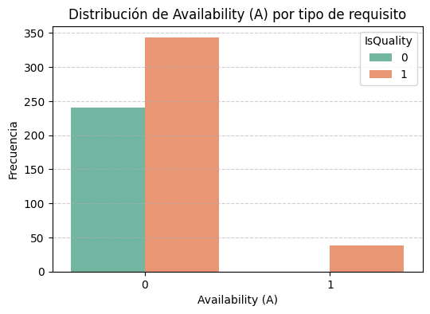

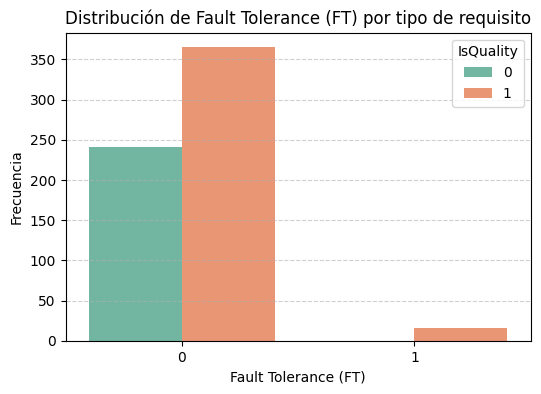

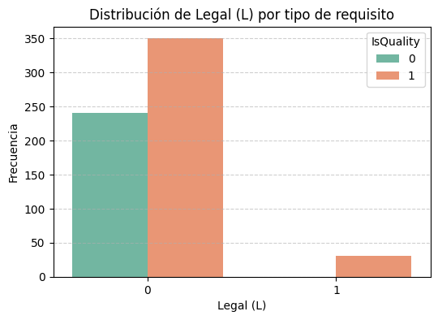

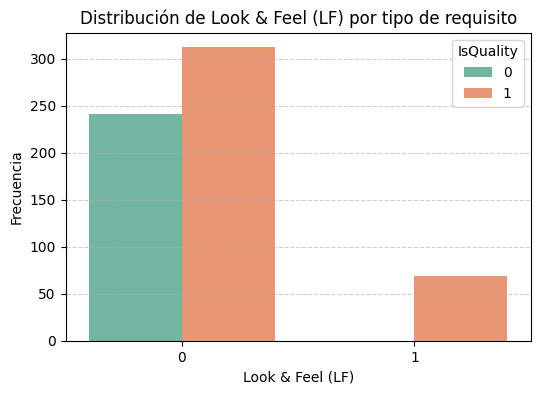

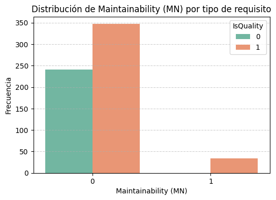

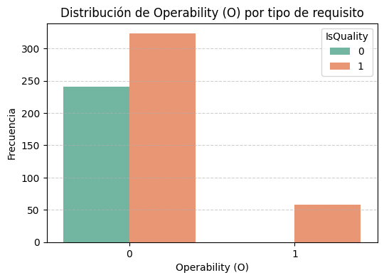

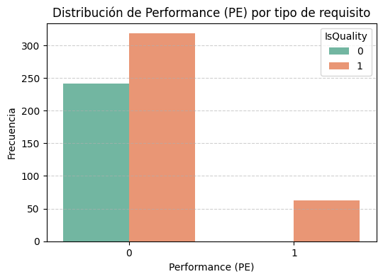

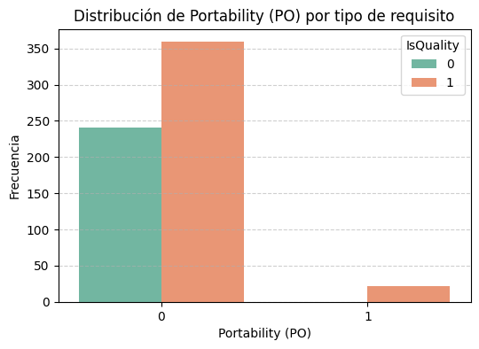

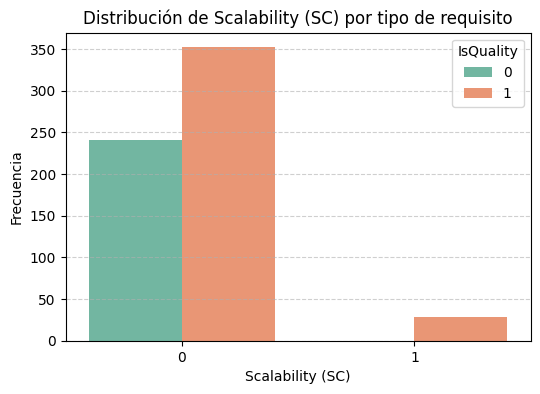

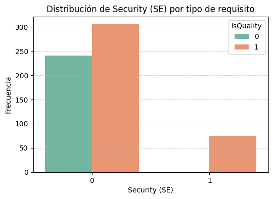

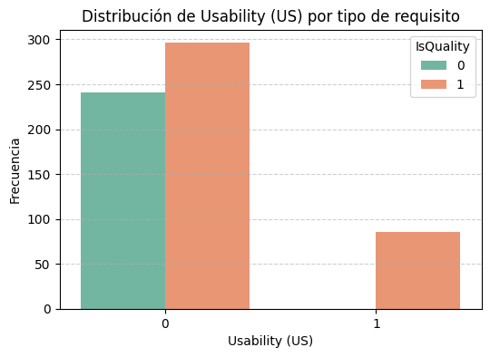

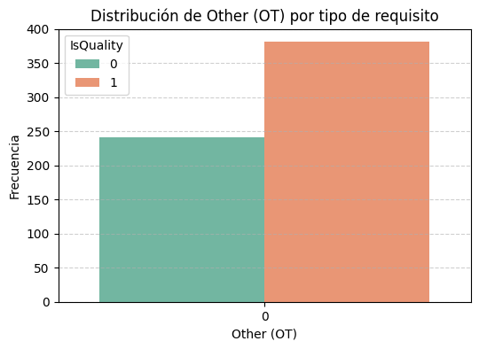

```python
for feature in features:
    plt.figure(figsize=(6, 4))
    sns.countplot(
        data=df,
        x=feature,
        hue=target,
        palette='Set2'
    )
    plt.title(f'Distribución de {feature} por tipo de requisito')
    plt.xlabel(feature)
    plt.ylabel('Frecuencia')
    plt.grid(axis='y', linestyle='--', alpha=0.6)
    plt.show()
```

```python
import pandas as pd
import seaborn as sns
import matplotlib.pyplot as plt

features = [
    'Availability (A)',
    'Fault Tolerance (FT)',
    'Legal (L)',
    'Look & Feel (LF)',
    'Maintainability (MN)',
    'Operability (O)',
    'Performance (PE)',
    'Portability (PO)',
    'Scalability (SC)',
    'Security (SE)',
    'Usability (US)',
    'Other (OT)'
]

target = 'IsQuality'

cols_corr = features + [target]
```

Dado que las variables son binarias, el coeficiente de correlación de Pearson es equivalente al coeficiente φ (phi), lo que lo convierte en una medida adecuada para evaluar asociaciones entre pares de variables.

El análisis de correlación se realiza tanto entre las características como entre cada característica y la variable objetivo. Este procedimiento permite identificar posibles redundancias entre atributos y evaluar qué características presentan una mayor asociación con la clasificación de los requisitos.

```python
corr_matrix = df[cols_corr].corr(method='pearson')
corr_target = corr_matrix[target].drop(target).sort_values(ascending=False)
print(corr_target)
```

```
Usability (US)          0.316423
Security (SE)           0.294498
Look & Feel (LF)        0.280936
Performance (PE)        0.266999
Operability (O)         0.255047
Availability (A)        0.202876
Maintainability (MN)    0.191248
Legal (L)               0.182152
Scalability (SC)        0.175880
Portability (PO)        0.152294
Fault Tolerance (FT)    0.129232
Other (OT)                   NaN
Name: IsQuality, dtype: float64
```

Aunque las variables son binarias, el factor de Fisher sigue siendo válido, ya que no mide dispersión continua sino la capacidad de una característica para separar clases. En el caso de variables binarias, la media representa una proporción y la varianza está determinada por dicha proporción, lo que permite cuantificar la separabilidad entre clases.

```python
import pandas as pd
import numpy as np

# -----------------------------
# Parámetros
# -----------------------------

df[target] = df[target].astype('category')

target = 'IsQuality'
features = [
    'Availability (A)',
    'Fault Tolerance (FT)',
    'Legal (L)',
    'Look & Feel (LF)',
    'Maintainability (MN)',
    'Operability (O)',
    'Performance (PE)',
    'Portability (PO)',
    'Scalability (SC)',
    'Security (SE)',
    'Usability (US)',
    'Other (OT)'
]

alpha1, alpha2 = 0.5, 0.5

# -----------------------------
# Fisher según TU definición
# -----------------------------
def get_fisher(feature_name):
    overall_mean = df[feature_name].mean()
    bgv = 0  # Between-group variance
    wgv = 0  # Within-group variance

    for c in df['IsQuality'].unique():
        subset = df[df['IsQuality'] == c][feature_name]
        n_c = len(subset)
        bgv += n_c * (subset.mean() - overall_mean) ** 2
        wgv += n_c * subset.var() if n_c > 1 else 0

    return bgv / wgv if wgv != 0 else 0
```

```python
df.info()
```

```
<class 'pandas.core.frame.DataFrame'>
RangeIndex: 622 entries, 0 to 621
Data columns (total 16 columns):
 #   Column                Non-Null Count  Dtype
---  ------                --------------  -----
 0   ProjectID             622 non-null    int64
 1   RequirementText       622 non-null    object
 2   IsFunctional          622 non-null    int64
 3   IsQuality             622 non-null    category
 4   Availability (A)      622 non-null    int64
 5   Fault Tolerance (FT)  622 non-null    int64
 6   Legal (L)             622 non-null    int64
 7   Look & Feel (LF)      622 non-null    int64
 8   Maintainability (MN)  622 non-null    int64
 9   Operability (O)       622 non-null    int64
 10  Performance (PE)      622 non-null    int64
 11  Portability (PO)      622 non-null    int64
 12  Scalability (SC)      622 non-null    int64
 13  Security (SE)         622 non-null    int64
 14  Usability (US)        622 non-null    int64
 15  Other (OT)            622 non-null    int64
dtypes: category(1), int64(14), object(1)
memory usage: 73.7+ KB
```

```python
alpha1, alpha2 = 0.5, 0.5

print("=== PASO 1 y 2: Fisher inicial ===")
print("--- PASO 1 y 2: Cálculo de Factores de Fisher Iniciales ---")

f_scores = {f: get_fisher(f) for f in features}

for f, score in f_scores.items():
    print(f"F({f}) = {score:.6f}")
```

```
=== PASO 1 y 2: Fisher inicial ===
--- PASO 1 y 2: Cálculo de Factores de Fisher Iniciales ---
F(Availability (A)) = 0.042813
F(Fault Tolerance (FT)) = 0.016940
F(Legal (L)) = 0.034228
F(Look & Feel (LF)) = 0.085463
F(Maintainability (MN)) = 0.037865
F(Operability (O)) = 0.069392
F(Performance (PE)) = 0.076559
F(Portability (PO)) = 0.023682
F(Scalability (SC)) = 0.031838
F(Security (SE)) = 0.094716
F(Usability (US)) = 0.110972
F(Other (OT)) = 0.000000
```

```python
s1 = max(f_scores, key=f_scores.get)
selected = [s1]
remaining = [f for f in features if f != s1]

print("\n--- PASO 3: Selección de s1 ---")
print(f"La mejor característica es '{s1}' con Fisher = {f_scores[s1]:.6f}")
```

```
--- PASO 3: Selección de s1 ---
La mejor característica es 'Usability (US)' con Fisher = 0.110972
```

```python
step = 2

while remaining:
    print(f"\n--- PASO {4 if step == 2 else 6}: Calculando s{step} ---")
    scores_step = {}
    k = len(selected) + 1

    for j in remaining:
        # Correlación promedio con las ya seleccionadas
        corrs = [abs(df[j].corr(df[s])) for s in selected]
        avg_corr = sum(corrs) / (k - 1)

        relevance = alpha1 * f_scores[j]
        redundancy = alpha2 * avg_corr
        total = relevance - redundancy

        scores_step[j] = total

        print(f"Evaluando '{j}':")
        print(f"  > Relevancia (Fisher): {relevance:.6f}")
        print(f"  > Redundancia (Corr promedio con {selected}): {redundancy:.6f}")
        print(f"  > PUNTAJE TOTAL: {total:.6f}")

    best_j = max(scores_step, key=scores_step.get)
    print(f" GANADOR para s{step}: '{best_j}'")

    selected.append(best_j)
    remaining.remove(best_j)
    step += 1
```

```
--- PASO 4: Calculando s2 ---
Evaluando 'Availability (A)':
  > Relevancia (Fisher): 0.021406
  > Redundancia (Corr promedio con ['Usability (US)']): 0.040972
  > PUNTAJE TOTAL: -0.019565
Evaluando 'Fault Tolerance (FT)':
  > Relevancia (Fisher): 0.008470
  > Redundancia (Corr promedio con ['Usability (US)']): 0.017540
  > PUNTAJE TOTAL: -0.009070
Evaluando 'Legal (L)':
  > Relevancia (Fisher): 0.017114
  > Redundancia (Corr promedio con ['Usability (US)']): 0.034805
  > PUNTAJE TOTAL: -0.017691
Evaluando 'Look & Feel (LF)':
  > Relevancia (Fisher): 0.042732
  > Redundancia (Corr promedio con ['Usability (US)']): 0.093678
  > PUNTAJE TOTAL: -0.050946
Evaluando 'Maintainability (MN)':
  > Relevancia (Fisher): 0.018932
  > Redundancia (Corr promedio con ['Usability (US)']): 0.016949
  > PUNTAJE TOTAL: 0.001983
Evaluando 'Operability (O)':
  > Relevancia (Fisher): 0.034696
  > Redundancia (Corr promedio con ['Usability (US)']): 0.055744
  > PUNTAJE TOTAL: -0.021048
Evaluando 'Performance (PE)':
  > Relevancia (Fisher): 0.038280
  > Redundancia (Corr promedio con ['Usability (US)']): 0.072842
  > PUNTAJE TOTAL: -0.034563
Evaluando 'Portability (PO)':
  > Relevancia (Fisher): 0.011841
  > Redundancia (Corr promedio con ['Usability (US)']): 0.038091
  > PUNTAJE TOTAL: -0.026251
Evaluando 'Scalability (SC)':
  > Relevancia (Fisher): 0.015919
  > Redundancia (Corr promedio con ['Usability (US)']): 0.033712
  > PUNTAJE TOTAL: -0.017793
Evaluando 'Security (SE)':
  > Relevancia (Fisher): 0.047358
  > Redundancia (Corr promedio con ['Usability (US)']): 0.037725
```

[output cut: 241 more lines]

```
  > Relevancia (Fisher): 0.011841
  > Redundancia (Corr promedio con ['Usability (US)', 'Security (SE)', 'Maintainability (MN)', 'Availability (A)', 'Operability (O)', 'Performance (PE)', 'Look & Feel (LF)', 'Scalability (SC)', 'Fault Tolerance (FT)', 'Legal (L)']): 0.032857
  > PUNTAJE TOTAL: -0.021017
Evaluando 'Other (OT)':
  > Relevancia (Fisher): 0.000000
  > Redundancia (Corr promedio con ['Usability (US)', 'Security (SE)', 'Maintainability (MN)', 'Availability (A)', 'Operability (O)', 'Performance (PE)', 'Look & Feel (LF)', 'Scalability (SC)', 'Fault Tolerance (FT)', 'Legal (L)']): nan
  > PUNTAJE TOTAL: nan
 GANADOR para s11: 'Portability (PO)'

--- PASO 6: Calculando s12 ---
Evaluando 'Other (OT)':
  > Relevancia (Fisher): 0.000000
  > Redundancia (Corr promedio con ['Usability (US)', 'Security (SE)', 'Maintainability (MN)', 'Availability (A)', 'Operability (O)', 'Performance (PE)', 'Look & Feel (LF)', 'Scalability (SC)', 'Fault Tolerance (FT)', 'Legal (L)', 'Portability (PO)']): nan
  > PUNTAJE TOTAL: nan
 GANADOR para s12: 'Other (OT)'
```

[output not shown]

```python
print("\n" + "=" * 45)
print("RANKING FINAL DE CARACTERÍSTICAS:")
for i, f in enumerate(selected, 1):
    print(f"s{i}: {f}")
```

```
=============================================
RANKING FINAL DE CARACTERÍSTICAS:
s1: Usability (US)
s2: Security (SE)
s3: Maintainability (MN)
s4: Availability (A)
s5: Operability (O)
s6: Performance (PE)
s7: Look & Feel (LF)
s8: Scalability (SC)
s9: Fault Tolerance (FT)
s10: Legal (L)
s11: Portability (PO)
s12: Other (OT)
```